# What makes some languages more difficult to learn than others?

## by Lauren Marar

This analysis will look at langauge difficulty for native English speakers and examine the linguistic features that distinguish easier and more difficult languages. Are there particular grammatical or phonological features that launch an otherwise ordinary language into the realm of difficult?

Note: Languages will be referred to as "easier" and "difficult" for short to represent their relative difficulty for an English speaker. Inherent difficulty independent of native language is not explored in this project.

### This analysis will utilize two datasets:

1. The World Atlas of Language Structures (WALS), which catalogues language features for 2,679 languages: https://www.kaggle.com/rtatman/world-atlas-of-language-structures
1. Language difficulty ratings as determined by the Foreign Service for 67 frequently studied languages: https://www.state.gov/m/fsi/sls/c78549.htm

### Langauge difficulty ratings

The Foreign Service categorized 67 languages into four difficulty levels. The difficulty levels were derived from the expected time it would take a native English speaker to reach "Professional Working Proficiency" (a score of 3 in speaking and reading on the Interagency Language Roundtable scale). English will be added as "level 0" for a comparison point.

## Exploring the dataset

#### How long does it take to learn a more difficult language, in comparison with an easier language?

(Click down to reveal the answer!)

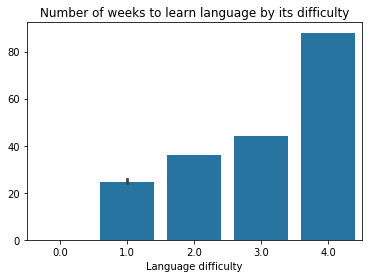

```python
sb.barplot(data=lang_levels_merge,x='difficulty',y='weeks',color=base_color)
plt.xlabel('Language difficulty')
plt.ylabel('')
plt.title('Number of weeks to learn language by its difficulty');
```

There is a non-linear relationship between the language difficulty rating and the number of weeks estimated to learn the language. Learning a category IV language is expected to take nearly twice as long as learning a category III language, whereas the difference between learning a category III and a category II language is relatively small.

#### How difficult are most languages in the dataset?

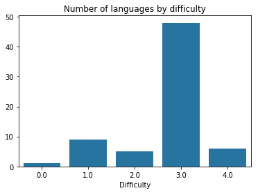

```python
base_color = sb.color_palette('PuBu')[4]
sb.countplot(data=lang_levels_merge, x='difficulty',color=base_color)
plt.xlabel('Difficulty')
plt.ylabel('')
plt.title('Number of languages by difficulty');
```

By far the most common difficulty level for the languages with ratings is category III.

#### How does language difficulty vary by language family?

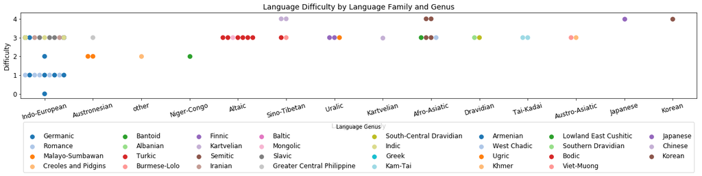

```python
fig = plt.figure(figsize=[23,3])
sb.swarmplot(data=FSI_langs,x='family',y='difficulty',hue='genus',palette='tab20',size=9)
plt.title('Language Difficulty by Language Family and Genus',fontsize=14)
plt.ylabel('Difficulty',fontsize=12)
plt.xlabel('Language Family',fontsize=12)
plt.xticks(rotation=15,fontsize=12)
plt.yticks([0,1,2,3,4],fontsize=12)
plt.legend(bbox_to_anchor=(.5,-.9),loc='lower center',title='Language Genus',ncol=8,fontsize=12);
```

Most languages within a family have the same difficulty rating. Other than the Indo-European family, only Austronesian, Sino-Tibetan, and Afro-Asiatic languages span more than one difficulty rating.

The Indo-European family has the largest range of difficulty levels, split primarily between category I and category III. This is intuitive as the category I genuses are Germanic and Romance (of Latin origin), which form the roots of English. The category III Indo-European languages comprise primarily the "Indo" part of the family, in other words, the South-Central Dravidian and Indic languages of South Asia.

But wait, there's more...

It looks like there is one Germanic language that is a category II difficulty and another that is a category III. Let's find out which ones they are:

**German:** Difficulty level 2 (36 weeks of study)

**Icelandic:** Difficulty level 3 (44 weeks of study)

It is interesting how both English and Icelandic are both Germanic languages, but are separated by 3 difficulty levels!

### 3. Which language families are included in the Foreign Service difficulty ratings? Which are missing?

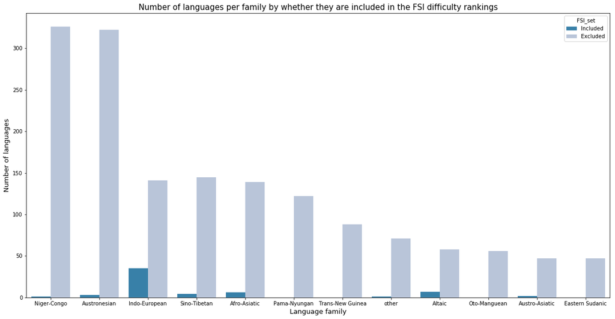

```python
fig=plt.figure(figsize=[20,10])
sb.countplot(data = lang_levels_merge, x = 'family', hue = 'FSI_set', palette='PuBu_r',
             order = families.iloc[:12].index)
plt.xlabel('Language family',fontsize=13)
plt.ylabel('Number of languages',fontsize=13)
plt.title('Number of languages per family by whether they are included in the FSI difficulty rankings',fontsize=15);
```

The chart reveals that the FSI rankings minimally cover the top two most diverse language families, Niger-Congo and Austronesian, which represent over 300 languages each. This analysis might miss out on some distinctive features of African and Polynesian languages! Also note that the bar heights are not proportional to the number of speakers. For example, the most widely spoken native langauge, Mandarin, is hiding in the fourth bar, Sino-Tibetan!

Anothe observation is that the Altaic language is relatively over-represented by the FSI rankings. Let's take a look at the languages included in that family:

```python
lang_levels_merge.query('family=="Altaic" & FSI_set=="Included"')
```

|  | language | difficulty | weeks | Name | genus | family | macroarea | lang_alias | _merge | FSI_set |
| --- | --- | --- | --- | --- | --- | --- | --- | --- | --- | --- |
| 15 | Azerbaijani | 3.0 | 44.0 | Azerbaijani | Turkic | Altaic | Eurasia | Azerbaijani | both | Included |
| 23 | Mongolian | 3.0 | 44.0 | Khalkha | Mongolic | Altaic | Eurasia | Mongolian | both | Included |
| 28 | Turkish | 3.0 | 44.0 | Turkish | Turkic | Altaic | Eurasia | Turkish | both | Included |
| 36 | Kazakh | 3.0 | 44.0 | Kazakh | Turkic | Altaic | Eurasia | Kazakh | both | Included |
| 37 | Kyrgyz | 3.0 | 44.0 | Kirghiz | Turkic | Altaic | Eurasia | Kyrgyz | both | Included |
| 44 | Turkmen | 3.0 | 44.0 | Turkmen | Turkic | Altaic | Eurasia | Turkmen | both | Included |
| 45 | Uzbek | 3.0 | 44.0 | Uzbek | Turkic | Altaic | Eurasia | Uzbek | both | Included |

The above table shows that the Foreign Service places an extra emphasis on Central Asian languages. All of these languages have a difficulty ranking of III.

Under and overrepresentation of langauge families in specific difficulty categories is likely to impact which linguistic features appear to be more common for specific difficulty groups.

### Occurance of linguistic features by language difficulty

The exploratory phase of the analysis involved systematically breaking down 144 linguistic features by language difficulty. Many of these features did not show strong differences across language, however several did. Click down to see an example of a weakly related feature as well as a strongly related feature. Click to the right to jump to the conclusion highlighting the most strongly related features.

#### Tone

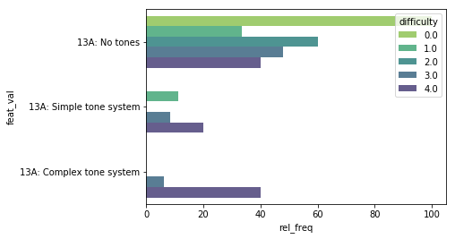

```python
tone = rel_freq.query('ID_num==13')
sb.barplot(data=tone,y='feat_val',x='rel_freq',hue='difficulty',palette='viridis_r',alpha=0.85);
```

Most languages with a complex tone system are category IV; however, just as many category IV languages have no tone system. Likely, the presence of a tone system contributes to a languages' difficulty, but there are plenty other features that can contribute to the difficulty without the presence of tones.

**Structure of yes/no questions by language difficulty**

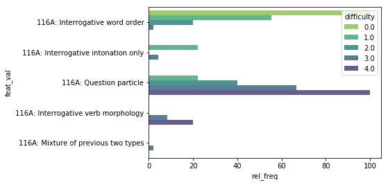

```python
polar_qs = rel_freq.query('ID_num==116')
sb.barplot(data=polar_qs,y='feat_val',x='rel_freq',hue='difficulty',palette='viridis_r',alpha=0.85);
```

## Key Findings

### Top linguistic distinctions between easy and difficult languages

The following charts explore the linguistic features that show the greatest variance by difficulty level. The charts display specific languages within the difficulty levels to illustrate whether the variance is uniform across a single level or if there is still variation within the level.

Notice where the shift occurs between the feature and the difficulty level; some features occur across category III and IV langauges, while other features only appear consistent across the most difficult langauges.

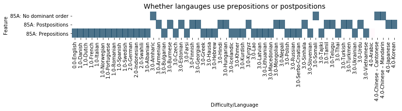

```python
adpositions_sum = lang_train.query('ID_num==85')
adpositions_feat = adpositions_sum.groupby(['difficulty','language','feat_val']).size()
adpositions_feat = adpositions_feat.reset_index(name='count')
adpositions_feat = adpositions_feat.pivot_table(columns=['difficulty','language'],index='feat_val',values='count')

fig = plt.figure(figsize=[12,1])

sb.heatmap(adpositions_feat,cmap='PuBu_r',cbar=False,alpha=.7)
plt.title('Whether langauges use prepositions or postpositions',fontsize=14)
plt.xlabel('Difficulty/Language')
plt.ylabel('Feature');
```

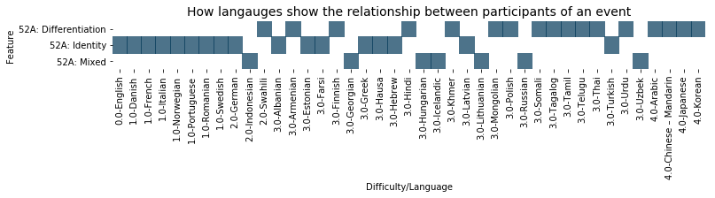

```python
relations_sum = lang_train.query('ID_num==52')
relations_feat = relations_sum.groupby(['difficulty','language','feat_val']).size()
relations_feat = relations_feat.reset_index(name='count')
relations_feat = relations_feat.pivot_table(columns=['difficulty','language'],index='feat_val',values='count')

fig = plt.figure(figsize=[12,1])

sb.heatmap(relations_feat,cmap='PuBu_r',cbar=False,alpha=.7)
plt.title('How langauges show the relationship between participants of an event',fontsize=14)
plt.xlabel('Difficulty/Language')
plt.ylabel('Feature');
```

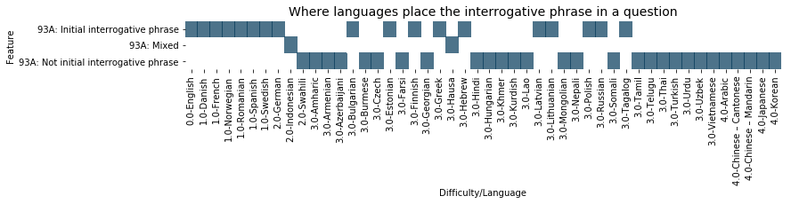

```python
questions_sum = lang_train.query('ID_num==93')
questions_feat = questions_sum.groupby(['difficulty','language','feat_val']).size()
questions_feat = questions_feat.reset_index(name='count')
questions_feat = questions_feat.pivot_table(columns=['difficulty','language'],index='feat_val',values='count')

fig = plt.figure(figsize=[12,1])

sb.heatmap(questions_feat,cmap='PuBu_r',cbar=False,alpha=.7)
plt.title('Where languages place the interrogative phrase in a question',fontsize=14)
plt.xlabel('Difficulty/Language')
plt.ylabel('Feature');
```

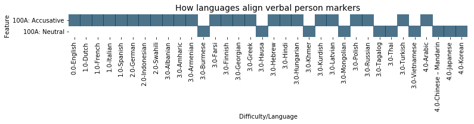

```python
person_sum = lang_train.query('ID_num==100')
person_feat = person_sum.groupby(['difficulty','language','feat_val']).size()
person_feat = person_feat.reset_index(name='count')
person_feat = person_feat.pivot_table(columns=['difficulty','language'],index='feat_val',values='count')

fig = plt.figure(figsize=[12,.7])

sb.heatmap(person_feat,cmap='PuBu_r',cbar=False,alpha=.7)
plt.title('How languages align verbal person markers',fontsize=14)
plt.xlabel('Difficulty/Language')
plt.ylabel('Feature');
```

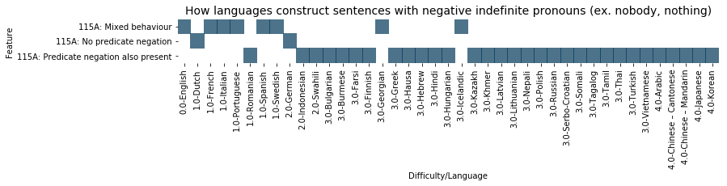

```python
negation_sum = lang_train.query('ID_num==115')
negation_feat = negation_sum.groupby(['difficulty','language','feat_val']).size()
negation_feat = negation_feat.reset_index(name='count')
negation_feat = negation_feat.pivot_table(columns=['difficulty','language'],index='feat_val',values='count')

fig = plt.figure(figsize=[12,1])

sb.heatmap(negation_feat,cmap='PuBu_r',cbar=False,alpha=.7)
plt.title('How languages construct sentences with negative indefinite pronouns (ex. nobody, nothing)',fontsize=14)
plt.xlabel('Difficulty/Language')
plt.ylabel('Feature');
```

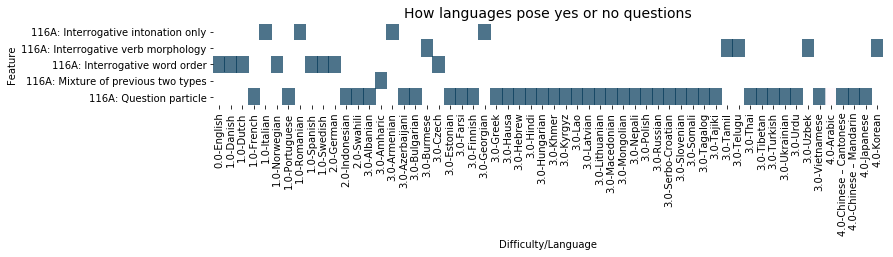

```python
polar_sum = lang_train.query('ID_num==116')
polar_feat = polar_sum.groupby(['difficulty','language','feat_val']).size()
polar_feat = polar_feat.reset_index(name='count')
polar_feat = polar_feat.pivot_table(columns=['difficulty','language'],index='feat_val',values='count')

fig = plt.figure(figsize=[12,1.5])

sb.heatmap(polar_feat,cmap='PuBu_r',cbar=False,alpha=.7)
plt.title('How languages pose yes or no questions',fontsize=14)
plt.xlabel('Difficulty/Language')
plt.ylabel('Feature');
```

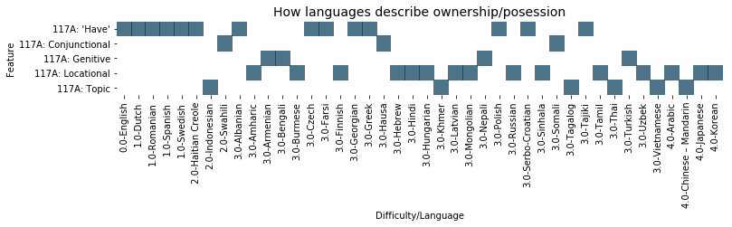

```python
predication_sum = lang_train.query('ID_num==117')
predication_feat = predication_sum.groupby(['difficulty','language','feat_val']).size()
predication_feat = predication_feat.reset_index(name='count')
predication_feat = predication_feat.pivot_table(columns=['difficulty','language'],index='feat_val',values='count')

fig = plt.figure(figsize=[12,1.5])

sb.heatmap(predication_feat,cmap='PuBu_r',cbar=False,alpha=.7)
plt.title('How languages describe ownership/posession',fontsize=14)
plt.xlabel('Difficulty/Language')
plt.ylabel('Feature');
```

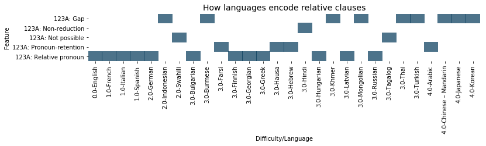

```python
gap_strategy_sum = lang_train.query('ID_num==123')
gap_strategy_feat = gap_strategy_sum.groupby(['difficulty','language','feat_val']).size()
gap_strategy_feat = gap_strategy_feat.reset_index(name='count')
gap_strategy_feat = gap_strategy_feat.pivot_table(columns=['difficulty','language'],index='feat_val',values='count')

fig = plt.figure(figsize=[12,1.5])

sb.heatmap(gap_strategy_feat,cmap='PuBu_r',cbar=False,alpha=.7)
plt.title('How languages encode relative clauses',fontsize=14)
plt.xlabel('Difficulty/Language')
plt.ylabel('Feature');
```

## Conclusions

It is possible that some of these features might not actually make a language difficult (such as the absence of definite articles.) Moreover, there may be features not listed above that, when combined with several other features, raise the difficulty of a language. It may be that there are several ways to make a language difficult, by combining a number of unique features, such as that no single feature stands out as the leading cause of language difficulty.

### Further research

- A regression analysis may better identify if the interaction of multiple features contributes to a language's difficulty.
- Another challenge was that the frequency of values associated with each linguistic feature were not evenly distributed. Binning values may help discern trends in difficulty.

### Even further research

In conclusion, it may very well be that those rare category IV languages stem from the perfect storm of a unique set of features, that

> *Easy languages are all alike; every difficult language is difficult in its own way.*